# Seminario Hadley Wickham

Grupo de investigación Sirius- Comunidad R Pereira

Junio 01, 2016

# Objetivos

- Exponer los principales conceptos de la regresión lineal.
- Describir la forma de realizar modelos de regresión lineal desde el lenguaje de programación R

# Variable aleatoria

Variable que es afectada por el azar.

Ejemplos:

- Valor al lanzar un dado
- Estatura de un grupo de personas
- Ventas de una empresa.

# variables aleatorias discreta

Para modelar este tipo de variables se les asocia una probablidad de ocurrencia a cada valor que puede tomar.

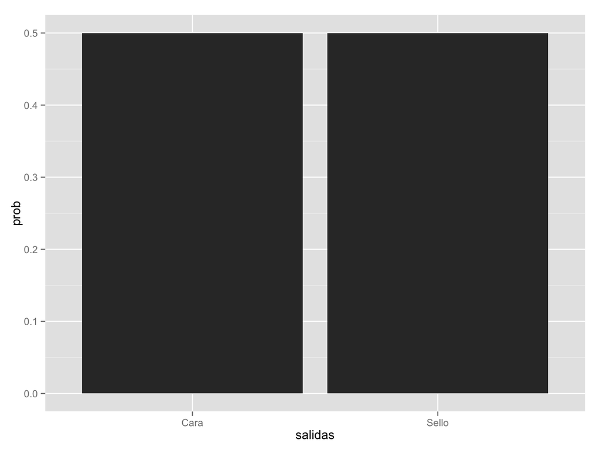

# variables aleatorias continua

Ejemplo estatura:

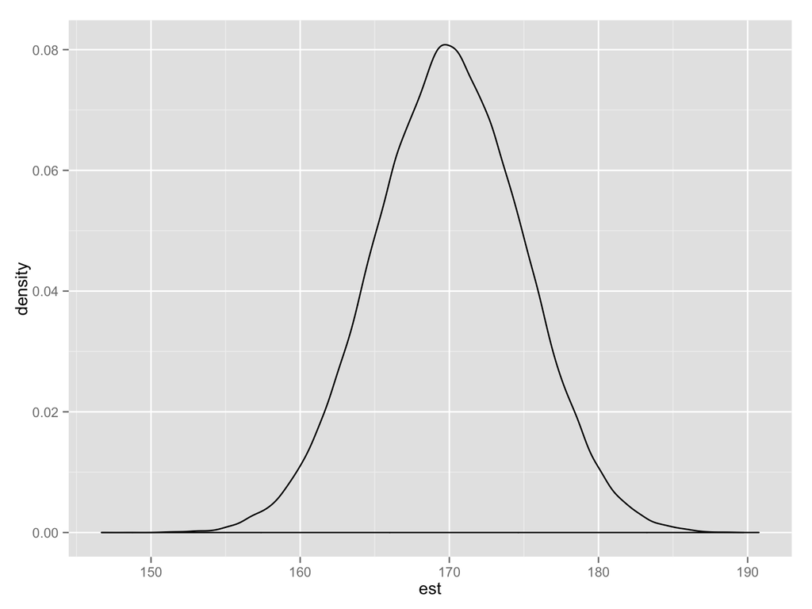

# Que es modelo de regresión lineal

Método matemático para modelar las relaciones existentes entre una variable dependiente (Y) con una o varias variables independiente (X).

# Como relacionarlas dos variables

Supongamos que tenemos las siguientes dos variables y queremos conocer su relación

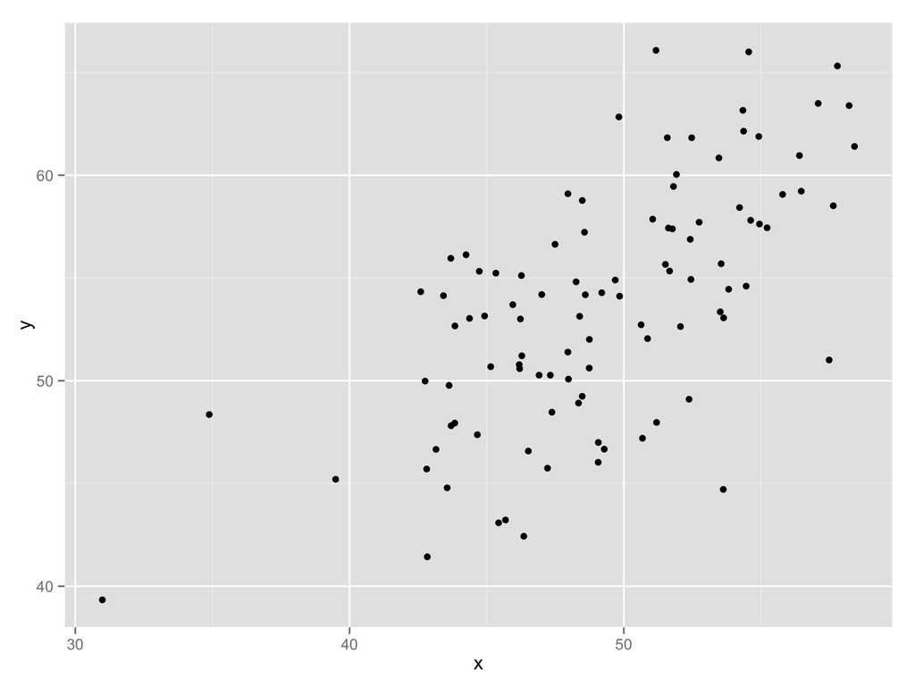

# Modelo de regresión simple

Para modelar la relación se plantea una relación lineal entre ambas variables.

Para esto se plantea un modelo lineal, aditivo.

$Y=\beta_{0}+\beta_{1}X+\epsilon$

donde la $\beta_{0}$ nos dice el valor que tomaría el modelo si x valiera cero (en el caso que fuera posible) y $\beta_{1}$ es la relación existente entre la variable x y la variable y.

# Utilidades

- Realizar pronósticos usando el modelo construido.
- Realizar proceso de inferencia.

# Parámetros de modelo

Dependiendo del valor que le demos a los parámetros tendremos un modelo diferente

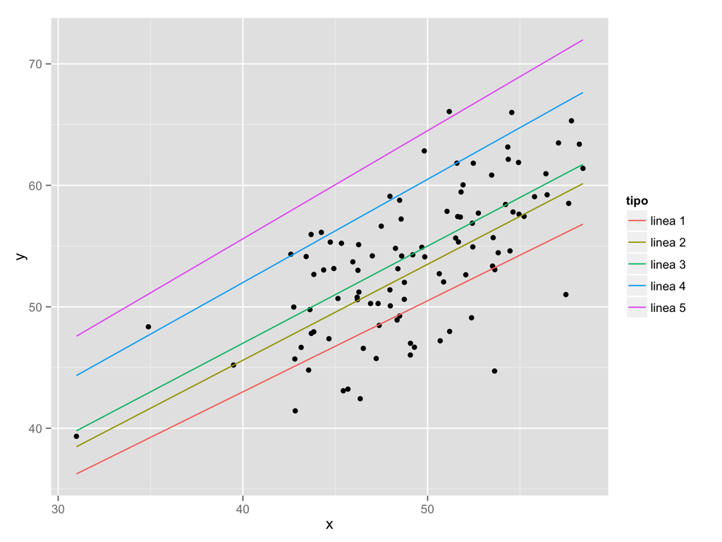

# Errores del modelo

Los errores del modelo son la diferencia del valor real de la variable Y y el valor estimado por el modelo.

$\epsilon=Y -(\beta_{0}+\beta_{1}X)$

Si denotamos el valor de Y estimado por el modelo como:

$\hat{Y}=\beta_{0}+\beta_{1}X$

tenemos que el error es igual a:

$\epsilon = Y - \hat{Y}$

# Errores del modelo

gráficamente los errores son:

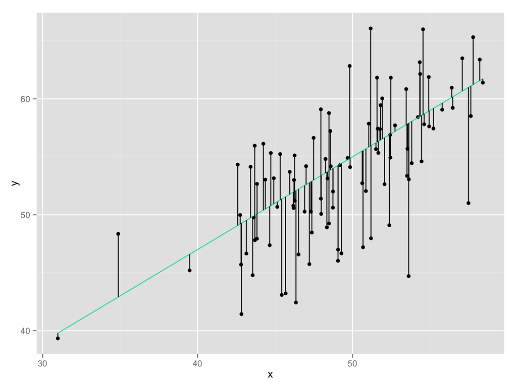

# Cálculo de los parámetros

Para estimar los parámetros del modelo se utiliza el método de mínimos cuadrados,en el cual se busca encontrar los valores que minimicen los errores al cuadrado.

$min: \sum \epsilon ^{2} =\sum (Y -(\beta_{0}+\beta_{1}X))^{2}$

# Interpretación del modelo de regresión

supongamos que podemos dejar fijo el valor de x, además, que el error tiene media cero y varianza $\sigma^{2}$

$E(y\mid x)=\mu_{y\mid x}=E(\beta_{0}+\beta_{1}X +\epsilon)=\beta_{0}+\beta_{1}X$

la respuesta media esta dada por el modelo (modelo de medias de Y)

$Var(y\mid x)=\sigma_{y\mid x}=Var(\beta_{0}+\beta_{1}X +\epsilon)=\sigma^{2}$

# Interpretación gráfica

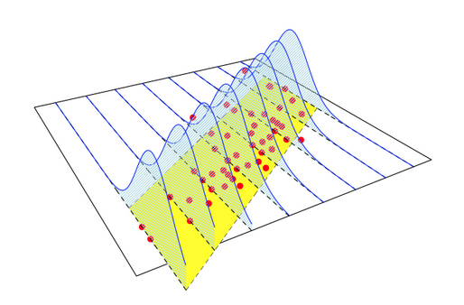

# Supuestos de modelo de regresión

Para construir un modelo de regresión se tiene ciertos supuestos, a continuación se mencionaran los más importantes:

- La relación entre las variables independientes y la dependiente es *lineal*
- El efecto de las variables es *aditivo*
- los errores del modelo son independientes
- Los errores del modelo tiene una distribución normal.
- La varianza de los errores es constante. (Homocedasticidad)
- La media de los errores es igual a cero.

# linealidad

Porque es la relación no trivial más simple que existe.

consecuencias: las predicciones del modelo tendrán serios errores, especialmente cuando se proyecta fuera del rango de la muestra

Solución: Pueden ser transformados los datos para cumplir linealidad.

# Modelo aditivo

Implica que el efecto que tiene una variable sobre Y, es independiente del valor que tomen las otras variables dependientes. Este supuesto es muy fuerte porque está directamente implicito en el modelo matemático.

consecuencias: las predicciones del modelo tendrán serios errores, especialmente cuando se proyecta fuera del rango de la muestra.

Para resolver este problema es necesario conocer muy bien los datos, e ingresar muy bien las variables independientes, además se puede ingresar un término que modele la interación.

# Independencia

Implica que el modelo puede ser mejorado, se pueden deber a problemas de linealidad, analizar la autocorrelación de los errores.

# Homocedasticidad

Este problema puede generar problemas en los análisis del modelo, principalmente cuando se estén construyendo intervalos de confianza.

por lo general cuando se tiene este problema se plantean transformaciones a los datos, especialmente transformaciones logarítmicas.

# Normalidad

Puede generar problemas en las pruebas de significacia (identificar si el efecto de las variables es diferente de cero),afectar la construcción de intervalos de confianza, y la estimación de los valores de los parámetros.

# Regresión lineal simple en R

Vamos a mostrar un primer ejemplo de un modelo de regresión simple, queremos conocer la relación existente entre la resistencia de unas piezas y su tiempo de vida. (ejemplo del libro “Introducción al análisis de regresión lineal, Montgomery et al.”)

```r
motor<-read.csv("Datosmotor.csv",header=T)
str(motor)
```

```
## 'data.frame':    20 obs. of  3 variables:
##  $ ID          : int  1 2 3 4 5 6 7 8 9 10 ...
##  $ Resistencia : num  2159 1678 2316 2061 2208 ...
##  $ Tiempo_pieza: num  15.5 23.8 8 17 5.5 ...
```

# Gráfica de los datos

Luego se deben graficar los datos del modelo

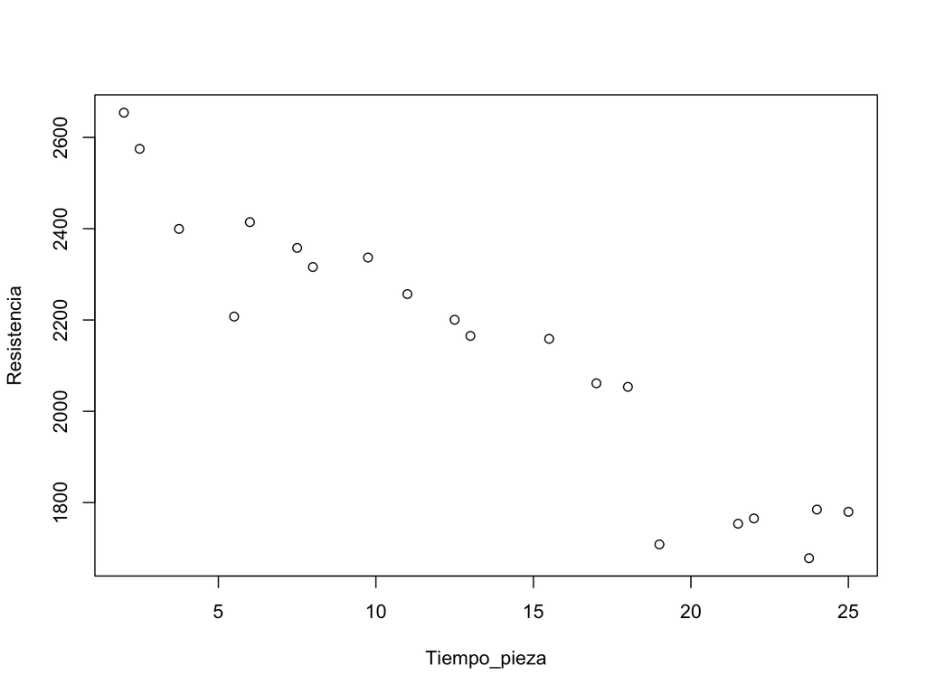

```r
plot(data=motor,Resistencia~Tiempo_pieza)
```

# Ejemplo 1 Regresión simple

```r
lmmotor<-lm(data=motor,Resistencia~Tiempo_pieza)
lmmotor
```

```
##
## Call:
## lm(formula = Resistencia ~ Tiempo_pieza, data = motor)
##
## Coefficients:
##  (Intercept)  Tiempo_pieza
##      2627.82        -37.15
```

El modelo que estimamos para los datos es el siguiente:

$\hat{y}=2627.82-37.15x$